# Risk Factor Analysis

## Outcome Variable

**Outcome Variable:** wasted

## Predictor Variables

**Intervention Variable:** birthlen

**Adjustment Set:**

- arm
- sex
- W_mage
- meducyrs
- feducyrs
- hhwealth_quart
- vagbrth
- W_nrooms
- brthmon
- W_parity
- impfloor
- impsan
- safeh20
- delta_W_mage
- delta_meducyrs
- delta_feducyrs
- delta_hhwealth_quart
- delta_vagbrth
- delta_W_nrooms
- delta_brthmon
- delta_W_parity
- delta_impfloor
- delta_impsan
- delta_safeh20

## Stratifying Variables

The analysis was stratified on these variable(s):

- agecat
- studyid
- country

## Data Summary

| agecat | studyid | country | birthlen | wasted | n_cell | n |
| --- | --- | --- | --- | --- | --- | --- |
| Birth | ki0047075b-MAL-ED | BANGLADESH | >=50 cm | 0 | 19 | 241 |
| Birth | ki0047075b-MAL-ED | BANGLADESH | >=50 cm | 1 | 10 | 241 |
| Birth | ki0047075b-MAL-ED | BANGLADESH | <48 cm | 0 | 110 | 241 |
| Birth | ki0047075b-MAL-ED | BANGLADESH | <48 cm | 1 | 18 | 241 |
| Birth | ki0047075b-MAL-ED | BANGLADESH | [48-50) cm | 0 | 72 | 241 |
| Birth | ki0047075b-MAL-ED | BANGLADESH | [48-50) cm | 1 | 12 | 241 |
| Birth | ki0047075b-MAL-ED | BRAZIL | >=50 cm | 0 | 31 | 183 |
| Birth | ki0047075b-MAL-ED | BRAZIL | >=50 cm | 1 | 3 | 183 |
| Birth | ki0047075b-MAL-ED | BRAZIL | <48 cm | 0 | 72 | 183 |
| Birth | ki0047075b-MAL-ED | BRAZIL | <48 cm | 1 | 1 | 183 |
| Birth | ki0047075b-MAL-ED | BRAZIL | [48-50) cm | 0 | 74 | 183 |
| Birth | ki0047075b-MAL-ED | BRAZIL | [48-50) cm | 1 | 2 | 183 |
| Birth | ki0047075b-MAL-ED | INDIA | >=50 cm | 0 | 22 | 203 |
| Birth | ki0047075b-MAL-ED | INDIA | >=50 cm | 1 | 3 | 203 |
| Birth | ki0047075b-MAL-ED | INDIA | <48 cm | 0 | 87 | 203 |
| Birth | ki0047075b-MAL-ED | INDIA | <48 cm | 1 | 17 | 203 |
| Birth | ki0047075b-MAL-ED | INDIA | [48-50) cm | 0 | 61 | 203 |
| Birth | ki0047075b-MAL-ED | INDIA | [48-50) cm | 1 | 13 | 203 |
| Birth | ki0047075b-MAL-ED | NEPAL | >=50 cm | 0 | 33 | 168 |
| Birth | ki0047075b-MAL-ED | NEPAL | >=50 cm | 1 | 5 | 168 |
| Birth | ki0047075b-MAL-ED | NEPAL | <48 cm | 0 | 53 | 168 |
| Birth | ki0047075b-MAL-ED | NEPAL | <48 cm | 1 | 11 | 168 |
| Birth | ki0047075b-MAL-ED | NEPAL | [48-50) cm | 0 | 62 | 168 |
| Birth | ki0047075b-MAL-ED | NEPAL | [48-50) cm | 1 | 4 | 168 |
| Birth | ki0047075b-MAL-ED | PERU | >=50 cm | 0 | 33 | 279 |
| Birth | ki0047075b-MAL-ED | PERU | >=50 cm | 1 | 1 | 279 |
| Birth | ki0047075b-MAL-ED | PERU | <48 cm | 0 | 131 | 279 |
| Birth | ki0047075b-MAL-ED | PERU | <48 cm | 1 | 3 | 279 |
| Birth | ki0047075b-MAL-ED | PERU | [48-50) cm | 0 | 109 | 279 |
| Birth | ki0047075b-MAL-ED | PERU | [48-50) cm | 1 | 2 | 279 |

[output cut: 432 more lines]

The following strata were considered:

- agecat: 24 months, studyid: ki0047075b-MAL-ED, country: BANGLADESH
- agecat: 24 months, studyid: ki0047075b-MAL-ED, country: BRAZIL
- agecat: 24 months, studyid: ki0047075b-MAL-ED, country: INDIA
- agecat: 24 months, studyid: ki0047075b-MAL-ED, country: NEPAL
- agecat: 24 months, studyid: ki0047075b-MAL-ED, country: PERU
- agecat: 24 months, studyid: ki0047075b-MAL-ED, country: SOUTH AFRICA
- agecat: 24 months, studyid: ki0047075b-MAL-ED, country: TANZANIA, UNITED REPUBLIC OF
- agecat: 24 months, studyid: ki1000108-CMC-V-BCS-2002, country: INDIA
- agecat: 24 months, studyid: ki1000108-IRC, country: INDIA
- agecat: 24 months, studyid: ki1017093-NIH-Birth, country: BANGLADESH
- agecat: 24 months, studyid: ki1017093b-PROVIDE, country: BANGLADESH
- agecat: 24 months, studyid: ki1017093c-NIH-Crypto, country: BANGLADESH
- agecat: 24 months, studyid: ki1101329-Keneba, country: GAMBIA
- agecat: 24 months, studyid: ki1114097-CMIN, country: BANGLADESH
- agecat: 24 months, studyid: ki1114097-CMIN, country: PERU
- agecat: 24 months, studyid: ki1114097-CONTENT, country: PERU
- agecat: 24 months, studyid: ki1119695-PROBIT, country: BELARUS
- agecat: 24 months, studyid: ki1126311-ZVITAMBO, country: ZIMBABWE
- agecat: 24 months, studyid: ki1135781-COHORTS, country: GUATEMALA
- agecat: 24 months, studyid: ki1135781-COHORTS, country: INDIA
- agecat: 24 months, studyid: ki1135781-COHORTS, country: PHILIPPINES
- agecat: 24 months, studyid: kiGH5241-JiVitA-3, country: BANGLADESH
- agecat: 24 months, studyid: kiGH5241-JiVitA-4, country: BANGLADESH
- agecat: 6 months, studyid: ki0047075b-MAL-ED, country: BANGLADESH
- agecat: 6 months, studyid: ki0047075b-MAL-ED, country: BRAZIL
- agecat: 6 months, studyid: ki0047075b-MAL-ED, country: INDIA
- agecat: 6 months, studyid: ki0047075b-MAL-ED, country: NEPAL
- agecat: 6 months, studyid: ki0047075b-MAL-ED, country: PERU
- agecat: 6 months, studyid: ki0047075b-MAL-ED, country: SOUTH AFRICA
- agecat: 6 months, studyid: ki0047075b-MAL-ED, country: TANZANIA, UNITED REPUBLIC OF
- agecat: 6 months, studyid: ki1000108-CMC-V-BCS-2002, country: INDIA
- agecat: 6 months, studyid: ki1000108-IRC, country: INDIA
- agecat: 6 months, studyid: ki1000109-EE, country: PAKISTAN
- agecat: 6 months, studyid: ki1000109-ResPak, country: PAKISTAN
- agecat: 6 months, studyid: ki1000304b-SAS-CompFeed, country: INDIA
- agecat: 6 months, studyid: ki1017093-NIH-Birth, country: BANGLADESH
- agecat: 6 months, studyid: ki1017093b-PROVIDE, country: BANGLADESH
- agecat: 6 months, studyid: ki1017093c-NIH-Crypto, country: BANGLADESH
- agecat: 6 months, studyid: ki1101329-Keneba, country: GAMBIA
- agecat: 6 months, studyid: ki1114097-CMIN, country: BANGLADESH
- agecat: 6 months, studyid: ki1114097-CMIN, country: BRAZIL
- agecat: 6 months, studyid: ki1114097-CMIN, country: GUINEA-BISSAU
- agecat: 6 months, studyid: ki1114097-CMIN, country: PERU
- agecat: 6 months, studyid: ki1114097-CONTENT, country: PERU
- agecat: 6 months, studyid: ki1119695-PROBIT, country: BELARUS
- agecat: 6 months, studyid: ki1126311-ZVITAMBO, country: ZIMBABWE
- agecat: 6 months, studyid: ki1135781-COHORTS, country: GUATEMALA
- agecat: 6 months, studyid: ki1135781-COHORTS, country: INDIA
- agecat: 6 months, studyid: ki1135781-COHORTS, country: PHILIPPINES
- agecat: 6 months, studyid: kiGH5241-JiVitA-3, country: BANGLADESH
- agecat: 6 months, studyid: kiGH5241-JiVitA-4, country: BANGLADESH
- agecat: Birth, studyid: ki0047075b-MAL-ED, country: BANGLADESH
- agecat: Birth, studyid: ki0047075b-MAL-ED, country: BRAZIL
- agecat: Birth, studyid: ki0047075b-MAL-ED, country: INDIA
- agecat: Birth, studyid: ki0047075b-MAL-ED, country: NEPAL
- agecat: Birth, studyid: ki0047075b-MAL-ED, country: PERU
- agecat: Birth, studyid: ki0047075b-MAL-ED, country: SOUTH AFRICA
- agecat: Birth, studyid: ki0047075b-MAL-ED, country: TANZANIA, UNITED REPUBLIC OF
- agecat: Birth, studyid: ki1000108-CMC-V-BCS-2002, country: INDIA
- agecat: Birth, studyid: ki1000108-IRC, country: INDIA
- agecat: Birth, studyid: ki1000109-EE, country: PAKISTAN
- agecat: Birth, studyid: ki1000109-ResPak, country: PAKISTAN
- agecat: Birth, studyid: ki1000304b-SAS-CompFeed, country: INDIA
- agecat: Birth, studyid: ki1017093-NIH-Birth, country: BANGLADESH
- agecat: Birth, studyid: ki1017093c-NIH-Crypto, country: BANGLADESH
- agecat: Birth, studyid: ki1101329-Keneba, country: GAMBIA
- agecat: Birth, studyid: ki1114097-CMIN, country: BANGLADESH
- agecat: Birth, studyid: ki1114097-CMIN, country: BRAZIL
- agecat: Birth, studyid: ki1114097-CMIN, country: PERU
- agecat: Birth, studyid: ki1114097-CONTENT, country: PERU
- agecat: Birth, studyid: ki1119695-PROBIT, country: BELARUS
- agecat: Birth, studyid: ki1126311-ZVITAMBO, country: ZIMBABWE
- agecat: Birth, studyid: ki1135781-COHORTS, country: GUATEMALA
- agecat: Birth, studyid: ki1135781-COHORTS, country: INDIA
- agecat: Birth, studyid: ki1135781-COHORTS, country: PHILIPPINES
- agecat: Birth, studyid: kiGH5241-JiVitA-3, country: BANGLADESH
- agecat: Birth, studyid: kiGH5241-JiVitA-4, country: BANGLADESH

### Dropped Strata

Some strata were dropped due to rare outcomes:

- agecat: Birth, studyid: ki0047075b-MAL-ED, country: BRAZIL
- agecat: Birth, studyid: ki0047075b-MAL-ED, country: INDIA
- agecat: Birth, studyid: ki0047075b-MAL-ED, country: NEPAL
- agecat: Birth, studyid: ki0047075b-MAL-ED, country: PERU
- agecat: Birth, studyid: ki0047075b-MAL-ED, country: TANZANIA, UNITED REPUBLIC OF
- agecat: Birth, studyid: ki1000108-CMC-V-BCS-2002, country: INDIA
- agecat: Birth, studyid: ki1000109-EE, country: PAKISTAN
- agecat: Birth, studyid: ki1000109-ResPak, country: PAKISTAN
- agecat: Birth, studyid: ki1000304b-SAS-CompFeed, country: INDIA
- agecat: Birth, studyid: ki1017093-NIH-Birth, country: BANGLADESH
- agecat: Birth, studyid: ki1017093c-NIH-Crypto, country: BANGLADESH
- agecat: Birth, studyid: ki1114097-CMIN, country: BANGLADESH
- agecat: Birth, studyid: ki1114097-CMIN, country: BRAZIL
- agecat: Birth, studyid: ki1114097-CMIN, country: PERU
- agecat: Birth, studyid: ki1114097-CONTENT, country: PERU
- agecat: Birth, studyid: ki1119695-PROBIT, country: BELARUS
- agecat: 6 months, studyid: ki0047075b-MAL-ED, country: BANGLADESH
- agecat: 6 months, studyid: ki0047075b-MAL-ED, country: BRAZIL
- agecat: 6 months, studyid: ki0047075b-MAL-ED, country: INDIA
- agecat: 6 months, studyid: ki0047075b-MAL-ED, country: NEPAL
- agecat: 6 months, studyid: ki0047075b-MAL-ED, country: PERU
- agecat: 6 months, studyid: ki0047075b-MAL-ED, country: SOUTH AFRICA
- agecat: 6 months, studyid: ki0047075b-MAL-ED, country: TANZANIA, UNITED REPUBLIC OF
- agecat: 6 months, studyid: ki1000108-CMC-V-BCS-2002, country: INDIA
- agecat: 6 months, studyid: ki1000109-EE, country: PAKISTAN
- agecat: 6 months, studyid: ki1000109-ResPak, country: PAKISTAN
- agecat: 6 months, studyid: ki1017093-NIH-Birth, country: BANGLADESH
- agecat: 6 months, studyid: ki1017093b-PROVIDE, country: BANGLADESH
- agecat: 6 months, studyid: ki1017093c-NIH-Crypto, country: BANGLADESH
- agecat: 6 months, studyid: ki1114097-CMIN, country: BANGLADESH
- agecat: 6 months, studyid: ki1114097-CMIN, country: BRAZIL
- agecat: 6 months, studyid: ki1114097-CMIN, country: GUINEA-BISSAU
- agecat: 6 months, studyid: ki1114097-CMIN, country: PERU
- agecat: 6 months, studyid: ki1114097-CONTENT, country: PERU
- agecat: 6 months, studyid: ki1119695-PROBIT, country: BELARUS
- agecat: 6 months, studyid: ki1135781-COHORTS, country: GUATEMALA
- agecat: 24 months, studyid: ki0047075b-MAL-ED, country: BANGLADESH
- agecat: 24 months, studyid: ki0047075b-MAL-ED, country: BRAZIL
- agecat: 24 months, studyid: ki0047075b-MAL-ED, country: INDIA
- agecat: 24 months, studyid: ki0047075b-MAL-ED, country: NEPAL
- agecat: 24 months, studyid: ki0047075b-MAL-ED, country: PERU
- agecat: 24 months, studyid: ki0047075b-MAL-ED, country: SOUTH AFRICA
- agecat: 24 months, studyid: ki0047075b-MAL-ED, country: TANZANIA, UNITED REPUBLIC OF
- agecat: 24 months, studyid: ki1000108-CMC-V-BCS-2002, country: INDIA
- agecat: 24 months, studyid: ki1017093-NIH-Birth, country: BANGLADESH
- agecat: 24 months, studyid: ki1114097-CMIN, country: BANGLADESH
- agecat: 24 months, studyid: ki1114097-CMIN, country: PERU
- agecat: 24 months, studyid: ki1114097-CONTENT, country: PERU
- agecat: 24 months, studyid: ki1119695-PROBIT, country: BELARUS
- agecat: 24 months, studyid: ki1135781-COHORTS, country: GUATEMALA

## Methods Detail

We’re interested in the causal parameters $E[Y_a]$ for all values of $a \in \mathcal{A}$. These parameters represent the mean outcome if, possibly contrary to fact, we intervened to set all units to have $A=a$. Under the randomization and positivity assumptions, these are identified by the statistical parameters $\psi_a=E_W[E_{Y|A,W}(Y|A=a,W)]$. In addition, we’re interested in the mean of $Y$, $E[Y]$ under no intervention (the observed mean). We will estimate these parameters by using SuperLearner to fit the relevant likelihood factors – $E_{Y|A,W}(Y|A=a,W)$ and $p(A=a|W)$, and then updating our likelihood fit using a joint TMLE.

For unadjusted analyses ($W=\{\}$), initial likelihoods were estimated using Lrnr_glm to estimate the simple $E(Y|A)$ and Lrnr_mean to estimate $p(A)$. For adjusted analyses, a small library containing Lrnr_glmnet, Lrnr_xgboost, and Lrnr_mean was used.

Having estimated these parameters, we will then use the delta method to estimate relative risks and attributable risks relative to a prespecified baseline level of $A$.

# Results Detail

## Results Plots

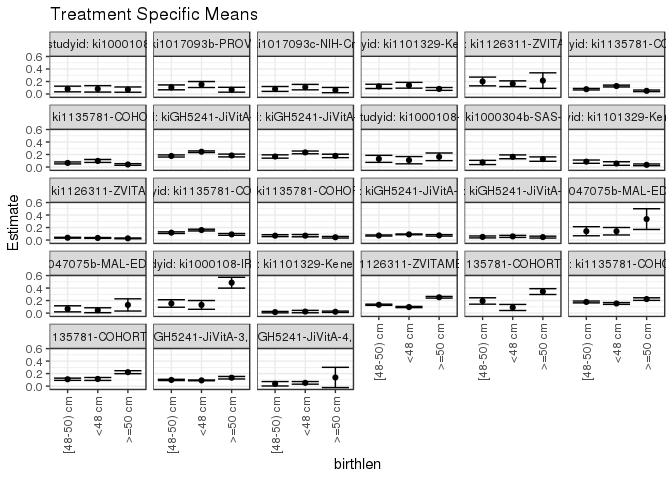

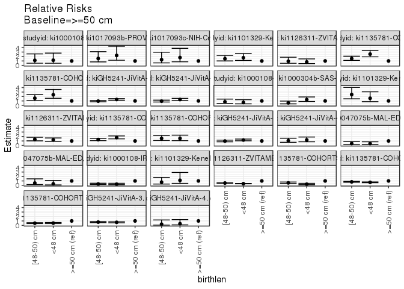

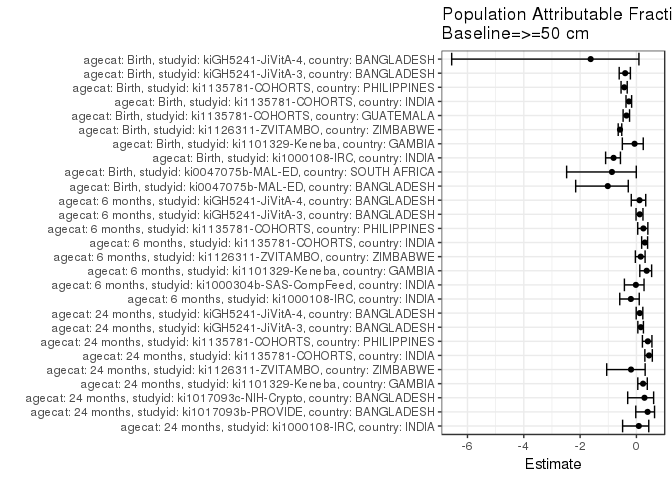

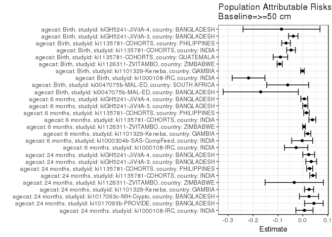

## Results Table

### Parameter: TSM

| agecat | studyid | country | intervention_level | baseline_level | estimate | ci_lower | ci_upper |
| --- | --- | --- | --- | --- | --- | --- | --- |
| Birth | ki0047075b-MAL-ED | BANGLADESH | >=50 cm | NA | 0.3349399 | 0.1691263 | 0.5007535 |
| Birth | ki0047075b-MAL-ED | BANGLADESH | <48 cm | NA | 0.1410068 | 0.0811255 | 0.2008881 |
| Birth | ki0047075b-MAL-ED | BANGLADESH | [48-50) cm | NA | 0.1411975 | 0.0687817 | 0.2136132 |
| Birth | ki0047075b-MAL-ED | SOUTH AFRICA | >=50 cm | NA | 0.1304348 | 0.0329223 | 0.2279473 |
| Birth | ki0047075b-MAL-ED | SOUTH AFRICA | <48 cm | NA | 0.0458716 | 0.0065208 | 0.0852223 |
| Birth | ki0047075b-MAL-ED | SOUTH AFRICA | [48-50) cm | NA | 0.0679612 | 0.0192621 | 0.1166602 |
| Birth | ki1000108-IRC | INDIA | >=50 cm | NA | 0.4859668 | 0.3990430 | 0.5728907 |
| Birth | ki1000108-IRC | INDIA | <48 cm | NA | 0.1305589 | 0.0604576 | 0.2006603 |
| Birth | ki1000108-IRC | INDIA | [48-50) cm | NA | 0.1533336 | 0.0932153 | 0.2134520 |
| Birth | ki1101329-Keneba | GAMBIA | >=50 cm | NA | 0.0209790 | 0.0104706 | 0.0314874 |
| Birth | ki1101329-Keneba | GAMBIA | <48 cm | NA | 0.0239044 | 0.0050006 | 0.0428082 |
| Birth | ki1101329-Keneba | GAMBIA | [48-50) cm | NA | 0.0153173 | 0.0040536 | 0.0265810 |
| Birth | ki1126311-ZVITAMBO | ZIMBABWE | >=50 cm | NA | 0.2524698 | 0.2393004 | 0.2656393 |
| Birth | ki1126311-ZVITAMBO | ZIMBABWE | <48 cm | NA | 0.0966878 | 0.0872456 | 0.1061301 |
| Birth | ki1126311-ZVITAMBO | ZIMBABWE | [48-50) cm | NA | 0.1330105 | 0.1239389 | 0.1420821 |
| Birth | ki1135781-COHORTS | GUATEMALA | >=50 cm | NA | 0.3438158 | 0.2972970 | 0.3903345 |
| Birth | ki1135781-COHORTS | GUATEMALA | <48 cm | NA | 0.0900362 | 0.0415722 | 0.1385003 |
| Birth | ki1135781-COHORTS | GUATEMALA | [48-50) cm | NA | 0.1934093 | 0.1424392 | 0.2443794 |
| Birth | ki1135781-COHORTS | INDIA | >=50 cm | NA | 0.2240785 | 0.2036802 | 0.2444768 |
| Birth | ki1135781-COHORTS | INDIA | <48 cm | NA | 0.1534780 | 0.1393339 | 0.1676221 |
| Birth | ki1135781-COHORTS | INDIA | [48-50) cm | NA | 0.1781387 | 0.1633285 | 0.1929488 |
| Birth | ki1135781-COHORTS | PHILIPPINES | >=50 cm | NA | 0.2228387 | 0.1989381 | 0.2467393 |
| Birth | ki1135781-COHORTS | PHILIPPINES | <48 cm | NA | 0.1143620 | 0.0909161 | 0.1378080 |
| Birth | ki1135781-COHORTS | PHILIPPINES | [48-50) cm | NA | 0.1096926 | 0.0917454 | 0.1276398 |
| Birth | kiGH5241-JiVitA-3 | BANGLADESH | >=50 cm | NA | 0.1341278 | 0.1139944 | 0.1542613 |
| Birth | kiGH5241-JiVitA-3 | BANGLADESH | <48 cm | NA | 0.0915471 | 0.0854282 | 0.0976661 |
| Birth | kiGH5241-JiVitA-3 | BANGLADESH | [48-50) cm | NA | 0.0987970 | 0.0890736 | 0.1085205 |
| Birth | kiGH5241-JiVitA-4 | BANGLADESH | >=50 cm | NA | 0.1383704 | -0.0237916 | 0.3005324 |
| Birth | kiGH5241-JiVitA-4 | BANGLADESH | <48 cm | NA | 0.0522099 | 0.0314755 | 0.0729443 |
| Birth | kiGH5241-JiVitA-4 | BANGLADESH | [48-50) cm | NA | 0.0373988 | 0.0020595 | 0.0727382 |

[output cut: 51 more lines]

### Parameter: E(Y)

| agecat | studyid | country | intervention_level | baseline_level | estimate | ci_lower | ci_upper |
| --- | --- | --- | --- | --- | --- | --- | --- |
| Birth | ki0047075b-MAL-ED | BANGLADESH | NA | NA | 0.1659751 | 0.1189041 | 0.2130461 |
| Birth | ki0047075b-MAL-ED | SOUTH AFRICA | NA | NA | 0.0697674 | 0.0386213 | 0.1009135 |
| Birth | ki1000108-IRC | INDIA | NA | NA | 0.2682216 | 0.2212677 | 0.3151755 |
| Birth | ki1101329-Keneba | GAMBIA | NA | NA | 0.0196767 | 0.0124580 | 0.0268954 |
| Birth | ki1126311-ZVITAMBO | ZIMBABWE | NA | NA | 0.1594921 | 0.1531776 | 0.1658066 |
| Birth | ki1135781-COHORTS | GUATEMALA | NA | NA | 0.2539683 | 0.2229196 | 0.2850169 |
| Birth | ki1135781-COHORTS | INDIA | NA | NA | 0.1769740 | 0.1674681 | 0.1864799 |
| Birth | ki1135781-COHORTS | PHILIPPINES | NA | NA | 0.1555709 | 0.1423748 | 0.1687670 |
| Birth | kiGH5241-JiVitA-3 | BANGLADESH | NA | NA | 0.0958686 | 0.0906699 | 0.1010673 |
| Birth | kiGH5241-JiVitA-4 | BANGLADESH | NA | NA | 0.0527086 | 0.0336587 | 0.0717585 |
| 6 months | ki1000108-IRC | INDIA | NA | NA | 0.1362468 | 0.1021125 | 0.1703810 |
| 6 months | ki1000304b-SAS-CompFeed | INDIA | NA | NA | 0.1240545 | 0.0993302 | 0.1487787 |
| 6 months | ki1101329-Keneba | GAMBIA | NA | NA | 0.0549369 | 0.0427642 | 0.0671096 |
| 6 months | ki1126311-ZVITAMBO | ZIMBABWE | NA | NA | 0.0320489 | 0.0282307 | 0.0358672 |
| 6 months | ki1135781-COHORTS | INDIA | NA | NA | 0.1289375 | 0.1205453 | 0.1373297 |
| 6 months | ki1135781-COHORTS | PHILIPPINES | NA | NA | 0.0592812 | 0.0503704 | 0.0681920 |
| 6 months | kiGH5241-JiVitA-3 | BANGLADESH | NA | NA | 0.0846506 | 0.0797924 | 0.0895088 |
| 6 months | kiGH5241-JiVitA-4 | BANGLADESH | NA | NA | 0.0531809 | 0.0435210 | 0.0628408 |
| 24 months | ki1000108-IRC | INDIA | NA | NA | 0.0769231 | 0.0504429 | 0.1034032 |
| 24 months | ki1017093b-PROVIDE | BANGLADESH | NA | NA | 0.1124567 | 0.0866788 | 0.1382347 |
| 24 months | ki1017093c-NIH-Crypto | BANGLADESH | NA | NA | 0.0875486 | 0.0630907 | 0.1120065 |
| 24 months | ki1101329-Keneba | GAMBIA | NA | NA | 0.1060038 | 0.0875152 | 0.1244923 |
| 24 months | ki1126311-ZVITAMBO | ZIMBABWE | NA | NA | 0.1798561 | 0.1429491 | 0.2167631 |
| 24 months | ki1135781-COHORTS | INDIA | NA | NA | 0.0908513 | 0.0826532 | 0.0990495 |
| 24 months | ki1135781-COHORTS | PHILIPPINES | NA | NA | 0.0682747 | 0.0582774 | 0.0782720 |
| 24 months | kiGH5241-JiVitA-3 | BANGLADESH | NA | NA | 0.2183007 | 0.2083024 | 0.2282989 |
| 24 months | kiGH5241-JiVitA-4 | BANGLADESH | NA | NA | 0.2013085 | 0.1867334 | 0.2158836 |

### Parameter: RR

| agecat | studyid | country | intervention_level | baseline_level | estimate | ci_lower | ci_upper |
| --- | --- | --- | --- | --- | --- | --- | --- |
| Birth | ki0047075b-MAL-ED | BANGLADESH | >=50 cm | >=50 cm | 1.0000000 | 1.0000000 | 1.0000000 |
| Birth | ki0047075b-MAL-ED | BANGLADESH | <48 cm | >=50 cm | 0.4209913 | 0.2192975 | 0.8081885 |
| Birth | ki0047075b-MAL-ED | BANGLADESH | [48-50) cm | >=50 cm | 0.4215606 | 0.2073892 | 0.8569074 |
| Birth | ki0047075b-MAL-ED | SOUTH AFRICA | >=50 cm | >=50 cm | 1.0000000 | 1.0000000 | 1.0000000 |
| Birth | ki0047075b-MAL-ED | SOUTH AFRICA | <48 cm | >=50 cm | 0.3516820 | 0.1127118 | 1.0973137 |
| Birth | ki0047075b-MAL-ED | SOUTH AFRICA | [48-50) cm | >=50 cm | 0.5210356 | 0.1849829 | 1.4675846 |
| Birth | ki1000108-IRC | INDIA | >=50 cm | >=50 cm | 1.0000000 | 1.0000000 | 1.0000000 |
| Birth | ki1000108-IRC | INDIA | <48 cm | >=50 cm | 0.2686581 | 0.1527708 | 0.4724540 |
| Birth | ki1000108-IRC | INDIA | [48-50) cm | >=50 cm | 0.3155228 | 0.2049936 | 0.4856478 |
| Birth | ki1101329-Keneba | GAMBIA | >=50 cm | >=50 cm | 1.0000000 | 1.0000000 | 1.0000000 |
| Birth | ki1101329-Keneba | GAMBIA | <48 cm | >=50 cm | 1.1394422 | 0.4468382 | 2.9055903 |
| Birth | ki1101329-Keneba | GAMBIA | [48-50) cm | >=50 cm | 0.7301240 | 0.2999046 | 1.7775020 |
| Birth | ki1126311-ZVITAMBO | ZIMBABWE | >=50 cm | >=50 cm | 1.0000000 | 1.0000000 | 1.0000000 |
| Birth | ki1126311-ZVITAMBO | ZIMBABWE | <48 cm | >=50 cm | 0.3829679 | 0.3428687 | 0.4277567 |
| Birth | ki1126311-ZVITAMBO | ZIMBABWE | [48-50) cm | >=50 cm | 0.5268371 | 0.4835829 | 0.5739603 |
| Birth | ki1135781-COHORTS | GUATEMALA | >=50 cm | >=50 cm | 1.0000000 | 1.0000000 | 1.0000000 |
| Birth | ki1135781-COHORTS | GUATEMALA | <48 cm | >=50 cm | 0.2618735 | 0.1502916 | 0.4562978 |
| Birth | ki1135781-COHORTS | GUATEMALA | [48-50) cm | >=50 cm | 0.5625377 | 0.4185457 | 0.7560671 |
| Birth | ki1135781-COHORTS | INDIA | >=50 cm | >=50 cm | 1.0000000 | 1.0000000 | 1.0000000 |
| Birth | ki1135781-COHORTS | INDIA | <48 cm | >=50 cm | 0.6849295 | 0.6019878 | 0.7792988 |
| Birth | ki1135781-COHORTS | INDIA | [48-50) cm | >=50 cm | 0.7949831 | 0.7030989 | 0.8988753 |
| Birth | ki1135781-COHORTS | PHILIPPINES | >=50 cm | >=50 cm | 1.0000000 | 1.0000000 | 1.0000000 |
| Birth | ki1135781-COHORTS | PHILIPPINES | <48 cm | >=50 cm | 0.5132056 | 0.4074095 | 0.6464747 |
| Birth | ki1135781-COHORTS | PHILIPPINES | [48-50) cm | >=50 cm | 0.4922511 | 0.4049613 | 0.5983563 |
| Birth | kiGH5241-JiVitA-3 | BANGLADESH | >=50 cm | >=50 cm | 1.0000000 | 1.0000000 | 1.0000000 |
| Birth | kiGH5241-JiVitA-3 | BANGLADESH | <48 cm | >=50 cm | 0.6825366 | 0.5808382 | 0.8020412 |
| Birth | kiGH5241-JiVitA-3 | BANGLADESH | [48-50) cm | >=50 cm | 0.7365885 | 0.6182395 | 0.8775930 |
| Birth | kiGH5241-JiVitA-4 | BANGLADESH | >=50 cm | >=50 cm | 1.0000000 | 1.0000000 | 1.0000000 |
| Birth | kiGH5241-JiVitA-4 | BANGLADESH | <48 cm | >=50 cm | 0.3773199 | 0.1094762 | 1.3004687 |
| Birth | kiGH5241-JiVitA-4 | BANGLADESH | [48-50) cm | >=50 cm | 0.2702807 | 0.0598437 | 1.2207069 |

[output cut: 51 more lines]

### Parameter: PAR

| agecat | studyid | country | intervention_level | baseline_level | estimate | ci_lower | ci_upper |
| --- | --- | --- | --- | --- | --- | --- | --- |
| Birth | ki0047075b-MAL-ED | BANGLADESH | >=50 cm | NA | -0.1689648 | -0.3198116 | -0.0181179 |
| Birth | ki0047075b-MAL-ED | SOUTH AFRICA | >=50 cm | NA | -0.0606673 | -0.1448580 | 0.0235233 |
| Birth | ki1000108-IRC | INDIA | >=50 cm | NA | -0.2177453 | -0.2835718 | -0.1519188 |
| Birth | ki1101329-Keneba | GAMBIA | >=50 cm | NA | -0.0013023 | -0.0084833 | 0.0058787 |
| Birth | ki1126311-ZVITAMBO | ZIMBABWE | >=50 cm | NA | -0.0929777 | -0.1032121 | -0.0827433 |
| Birth | ki1135781-COHORTS | GUATEMALA | >=50 cm | NA | -0.0898475 | -0.1189680 | -0.0607270 |
| Birth | ki1135781-COHORTS | INDIA | >=50 cm | NA | -0.0471045 | -0.0646933 | -0.0295157 |
| Birth | ki1135781-COHORTS | PHILIPPINES | >=50 cm | NA | -0.0672678 | -0.0845303 | -0.0500052 |
| Birth | kiGH5241-JiVitA-3 | BANGLADESH | >=50 cm | NA | -0.0382592 | -0.0573130 | -0.0192054 |
| Birth | kiGH5241-JiVitA-4 | BANGLADESH | >=50 cm | NA | -0.0856618 | -0.2401006 | 0.0687770 |
| 6 months | ki1000108-IRC | INDIA | >=50 cm | NA | -0.0268738 | -0.0736798 | 0.0199322 |
| 6 months | ki1000304b-SAS-CompFeed | INDIA | >=50 cm | NA | -0.0025265 | -0.0446929 | 0.0396399 |
| 6 months | ki1101329-Keneba | GAMBIA | >=50 cm | NA | 0.0199860 | 0.0079287 | 0.0320433 |
| 6 months | ki1126311-ZVITAMBO | ZIMBABWE | >=50 cm | NA | 0.0048860 | -0.0006515 | 0.0104236 |
| 6 months | ki1135781-COHORTS | INDIA | >=50 cm | NA | 0.0385706 | 0.0247646 | 0.0523766 |
| 6 months | ki1135781-COHORTS | PHILIPPINES | >=50 cm | NA | 0.0146440 | 0.0038473 | 0.0254406 |
| 6 months | kiGH5241-JiVitA-3 | BANGLADESH | >=50 cm | NA | 0.0099704 | -0.0003817 | 0.0203224 |
| 6 months | kiGH5241-JiVitA-4 | BANGLADESH | >=50 cm | NA | 0.0058421 | -0.0077987 | 0.0194828 |
| 24 months | ki1000108-IRC | INDIA | >=50 cm | NA | 0.0065005 | -0.0279054 | 0.0409065 |
| 24 months | ki1017093b-PROVIDE | BANGLADESH | >=50 cm | NA | 0.0445347 | 0.0072740 | 0.0817953 |
| 24 months | ki1017093c-NIH-Crypto | BANGLADESH | >=50 cm | NA | 0.0250486 | -0.0134555 | 0.0635528 |
| 24 months | ki1101329-Keneba | GAMBIA | >=50 cm | NA | 0.0249679 | 0.0068217 | 0.0431141 |
| 24 months | ki1126311-ZVITAMBO | ZIMBABWE | >=50 cm | NA | -0.0344296 | -0.1514299 | 0.0825707 |
| 24 months | ki1135781-COHORTS | INDIA | >=50 cm | NA | 0.0406582 | 0.0281865 | 0.0531300 |
| 24 months | ki1135781-COHORTS | PHILIPPINES | >=50 cm | NA | 0.0276676 | 0.0157608 | 0.0395743 |
| 24 months | kiGH5241-JiVitA-3 | BANGLADESH | >=50 cm | NA | 0.0338435 | 0.0120313 | 0.0556558 |
| 24 months | kiGH5241-JiVitA-4 | BANGLADESH | >=50 cm | NA | 0.0235959 | -0.0000380 | 0.0472298 |

### Parameter: PAF

| agecat | studyid | country | intervention_level | baseline_level | estimate | ci_lower | ci_upper |
| --- | --- | --- | --- | --- | --- | --- | --- |
| Birth | ki0047075b-MAL-ED | BANGLADESH | >=50 cm | NA | -1.0180129 | -2.1574790 | -0.2897555 |
| Birth | ki0047075b-MAL-ED | SOUTH AFRICA | >=50 cm | NA | -0.8695652 | -2.4787419 | -0.0047523 |
| Birth | ki1000108-IRC | INDIA | >=50 cm | NA | -0.8118111 | -1.0943527 | -0.5673862 |
| Birth | ki1101329-Keneba | GAMBIA | >=50 cm | NA | -0.0661838 | -0.5002825 | 0.2423108 |
| Birth | ki1126311-ZVITAMBO | ZIMBABWE | >=50 cm | NA | -0.5829614 | -0.6474040 | -0.5210397 |
| Birth | ki1135781-COHORTS | GUATEMALA | >=50 cm | NA | -0.3537746 | -0.4731478 | -0.2440745 |
| Birth | ki1135781-COHORTS | INDIA | >=50 cm | NA | -0.2661663 | -0.3699125 | -0.1702771 |
| Birth | ki1135781-COHORTS | PHILIPPINES | >=50 cm | NA | -0.4323932 | -0.5456787 | -0.3274105 |
| Birth | kiGH5241-JiVitA-3 | BANGLADESH | >=50 cm | NA | -0.3990797 | -0.6120719 | -0.2142288 |
| Birth | kiGH5241-JiVitA-4 | BANGLADESH | >=50 cm | NA | -1.6251944 | -6.5610270 | 0.0885305 |
| 6 months | ki1000108-IRC | INDIA | >=50 cm | NA | -0.1972434 | -0.5921885 | 0.0997348 |
| 6 months | ki1000304b-SAS-CompFeed | INDIA | >=50 cm | NA | -0.0203660 | -0.4268983 | 0.2703427 |
| 6 months | ki1101329-Keneba | GAMBIA | >=50 cm | NA | 0.3637991 | 0.1201437 | 0.5399799 |
| 6 months | ki1126311-ZVITAMBO | ZIMBABWE | >=50 cm | NA | 0.1524550 | -0.0375083 | 0.3076368 |
| 6 months | ki1135781-COHORTS | INDIA | >=50 cm | NA | 0.2991418 | 0.1858230 | 0.3966886 |
| 6 months | ki1135781-COHORTS | PHILIPPINES | >=50 cm | NA | 0.2470253 | 0.0459437 | 0.4057259 |
| 6 months | kiGH5241-JiVitA-3 | BANGLADESH | >=50 cm | NA | 0.1177827 | -0.0135154 | 0.2320714 |
| 6 months | kiGH5241-JiVitA-4 | BANGLADESH | >=50 cm | NA | 0.1098526 | -0.1829914 | 0.3302044 |
| 24 months | ki1000108-IRC | INDIA | >=50 cm | NA | 0.0845070 | -0.4909232 | 0.4378467 |
| 24 months | ki1017093b-PROVIDE | BANGLADESH | >=50 cm | NA | 0.3960160 | -0.0234595 | 0.6435651 |
| 24 months | ki1017093c-NIH-Crypto | BANGLADESH | >=50 cm | NA | 0.2861111 | -0.3102198 | 0.6110291 |
| 24 months | ki1101329-Keneba | GAMBIA | >=50 cm | NA | 0.2355378 | 0.0484248 | 0.3858579 |
| 24 months | ki1126311-ZVITAMBO | ZIMBABWE | >=50 cm | NA | -0.1914286 | -1.0558290 | 0.3095233 |
| 24 months | ki1135781-COHORTS | INDIA | >=50 cm | NA | 0.4475248 | 0.2993650 | 0.5643539 |
| 24 months | ki1135781-COHORTS | PHILIPPINES | >=50 cm | NA | 0.4052386 | 0.2127529 | 0.5506607 |
| 24 months | kiGH5241-JiVitA-3 | BANGLADESH | >=50 cm | NA | 0.1550318 | 0.0501105 | 0.2483639 |
| 24 months | kiGH5241-JiVitA-4 | BANGLADESH | >=50 cm | NA | 0.1172126 | -0.0084026 | 0.2271802 |